# Naive Bayes

## Introduction

Naive Bayes Classification is a category within Bayes’ Theorem that contains a collection of algorithms. The main purpose of using this type of algorithms is to classify data into predefined classes or categories. For this reason, Naive Bayes is considered a type of supervised learning, as the models are trained on labeled data, meaning that the data has been pre-classified. The main advantages of these algorithms are that they are simple, efficient, and useful in various applications, including record label data and text-labeled data. As the name implies, these methods are “naive”, meaning that they assume that the features used are independent in order to simplify the models and be computationally efficient. This assumption is usually not true in real-world cases, but the models perform well in practice.

Naive Bayes is based on the principles of probability and statistics, therefore, to understand how the algorithms work, we first need an introduction to Bayes’ theorem. *“Bayes’ theorem finds the probability of an event occurring given the probability of another event that has already occurred.”* To understand the function, we try to find the probability of the event $A$, given that the event $B$, which is the evidence, is true. The probability of $A$ is the prior of $A$, that is, the probability of the event before the evidence is seen.

**Bayes’ Thorem:**

$P(A|B) = \frac{P(B|A) \cdot P(A)}{P(B)}$

$P(A)$: Probability of $A$

$P(A|B)$: Poterior probability of $B$

The algorithm uses the theorem to compute the probability that a data point belongs to a particular class given its features. It combines the prior knowledge with the new evidence. In summary, Naive Bayes classifies data by evaluating the likelihood of each class based on the observed features.

## Objectives

Through this section we will focus in two analysis. First, we will use the record labeled data we have collected, cleaned, and explored in the previous sections. The data we will use is the Electric Vehicle Specifications dataset. With this analysis the goal is to understand if there is an existing pattern or relationship between different characteristics in order to classify them into the continent of origin. This is very useful to learn the manufacturing specifications and gain insights to draw conclusions about the desires for each market.

The second dataset we will use is the sentiment analysis results on the Lithium News data. The goal of this analysis is to understand if Naive Bayes classification algorithms are able to perform a similar procedure to identify sentiment analysis labels based on a reduced data set. This is very useful because sentiment analysis algorithms can be biased based on the connotations of certain words depending on the environment. By using Naive Bayes with trained data from a specific topic, the bias is reduced and the predictions should be more accurate. A third analysis is performed on the same dataset. The goal is to see if we can classify the articles into specific categories based on the vocabulary used, which are originally the publisher’s categories. Within these categories we find General, Business, Science and Technology.

## Methods

Within the Naive Bayes algorithms we can find Gaussian, Multinomial and Bernoulli. Each one is different from the others because they can handle specific characteristics of the data and have different applications. The choice of the appropriate model is crucial because it improves the results, the performance and the accuracy of the classifier. The following explanations aim to summarize the main differences between the algorithms for a better understanding of the following application and analysis.

*Gaussian Naive Bayes:* This first model is usually used when the features in the data set are continuous. The features typically follow a normal (Gaussian) distribution, and statistics such as the mean and standard deviation for each class are used to model the distribution.

*Multinomial Naive Bayes:* This second model is used when the features in the data set are discrete. The algorithm considers the frequency of occurrence of the feature within each class. An example of application is text data to perform natural language processing tasks such as text classification.

*Bernoulli Naive Bayes:* The third model is used for features that have a binary value. The algorithm focuses on whether the classification is yes or no, or true or false. This model is usually used in document classification tasks.

## Analysis

The analysis for this section includes three tabs, which we will observe below. As explained above, we will perform Gaussian Naive Bayes Classification on the Electric Vehicles Characteristics dataset, Multinimial Naive Bayes Classification on the Lithium News sentiment analysis results, and Lithium News publisher categories.

In this case, we used Python libraries to develop the analysis and effective visualizations to show the results. The libraries required and functions created for the analysis are listed below.

**Python Libraries**

```python
import pandas as pd
import numpy as np

import seaborn as sns
import matplotlib.pyplot as plt
import scipy
import sklearn
from scipy.stats import spearmanr

# Gaussian Naive Bayes
from sklearn.naive_bayes import GaussianNB

# Multinomial Naive Bayes
from sklearn.naive_bayes import MultinomialNB


# Split the data
from sklearn.model_selection import train_test_split

# Performance Metrics
from sklearn.metrics import accuracy_score, classification_report

import random

# Features Text Data
from sklearn.feature_extraction.text import CountVectorizer

from sklearn import metrics
```

**Fuction print_model_summary()**

```python
def print_model_summary(y_test, y_pred):
    print("Accuracy:", metrics.accuracy_score(y_test, y_pred))
    print("\n")
    print("Classification Report:")
    print("\n")
    print(metrics.classification_report(y_test, y_pred))

    cm = metrics.confusion_matrix(y_test, y_pred)
    sns.heatmap(cm, annot=True, fmt='g', cmap='Blues', xticklabels=model.classes_, yticklabels=model.classes_)
    plt.xlabel('Predicted')
    plt.ylabel('Actual')
    plt.title('Confusion Matrix')
    plt.show()
```

EV Characteristics

Lithium News Sentiments

Lithium News Categories

*Electric Vehicles Characteristics ~ Record Labeled Data*

### Data Selection

Based on the data available for analysis, we will use the numeric features; Battery, Efficiency, FastCharge, Price, Range, TopSpeed and Acceleration to predict the Continent where they were manufactured. For practical purposes, we converted the target feature; Continent, to be numeric.

**{python}**

```python
# Save dataframe as a new file
df_vehicles = pd.read_csv('../../data/01-modified-data/clean_vehicles.csv')

df_vehicles = df_vehicles.dropna()

x = df_vehicles.columns[df_vehicles.dtypes != 'object']

x = df_vehicles[x]

y = pd.Categorical(df_vehicles['Continent']).codes

df_vehicles.head(5).to_csv('../../data/02-visualization-data/df_vehicles.csv', index=False)
```

| Brand | CarName | Battery | Efficiency | FastCharge | Price | Range | TopSpeed | Acceleration | Continent |
| --- | --- | --- | --- | --- | --- | --- | --- | --- | --- |
| Abarth | Abarth 500e Hatchback | 37.8 | 168 | 370 | 37990 | 225 | 155 | 7.0 | Europe |
| Abarth | Abarth 500e Convertible | 37.8 | 168 | 370 | 40990 | 225 | 155 | 7.0 | Europe |
| Aiways | Aiways U6 | 60.0 | 171 | 430 | 47588 | 350 | 160 | 7.0 | Europe |
| Aiways | Aiways U5 | 60.0 | 190 | 380 | 39563 | 315 | 150 | 7.5 | Europe |
| Audi | Audi Q8 e-tron Sportback 50 quattro | 89.0 | 200 | 690 | 76650 | 445 | 200 | 6.0 | Europe |

### Results

With the goal of having an efficient and reproducible analysis, we created a function to train the Gaussian Naive Bayes model. This is useful for creating the model, fitting it, creating the test sets, and observing the performance of each set.

To split the data, we considered 20% of the total records for the test set and the remaining 80% for training. After applying the function to the analysis, we can see that we get an accuracy value for the training set and the test set. The accuracy value for the training set is approximately 0.57 while the test set is approximately 0.63.

**Fuction train_GNB_model()**

```python
def train_GNB_model(x_train,y_train,x_test,y_test,i_print=False):

    # INSERT CODE HERE
    gnb_model = GaussianNB()

    gnb_model.fit(x_train, y_train)

    y_train_pred = gnb_model.predict(x_train)
    y_test_pred = gnb_model.predict(x_test)

    train_accuracy = accuracy_score(y_train, y_train_pred)
    test_accuracy = accuracy_score(y_test, y_test_pred)

    if i_print == True:
        print(train_accuracy*100, test_accuracy*100)

    return train_accuracy, test_accuracy
```

**{python}**

```python
x_train, x_test, y_train, y_test = train_test_split(x, y, test_size=0.2, random_state=42)

print("Train Set Accuracy:", train_GNB_model(x_train,y_train,x_test,y_test,i_print=False)[0])
print("Test Set Accuracy:", train_GNB_model(x_train,y_train,x_test,y_test,i_print=False)[1])
```

```
Train Set Accuracy: 0.5714285714285714
```

```
Test Set Accuracy: 0.6290322580645161
```

### Conclusion

Based on the results obtained, we can observe that the accuracy of the training set is lower than the accuracy of the test set. Considering the small number of data points used for this analysis, the results are considered good. So far, we can observe that the values for the analyzed features are useful to determine the class to which they belong.

For future analysis, it would be useful to include additional data points so that the analysis is well balanced. We can also consider adding another target label to understand, for example, if we can target the country where the electric vehicles are manufactured.

*Lithium News Sentiments ~ Text Labeled Data*

### Data Selection

The relevant data for this analysis is the article content which appears as *text* and the *label* assigned by the IBM sentiment analysis algorithm. This data requires additional data cleaning as the text needs to be vectorized. This means that we will produce a sparse representation of the counts for the tokens. The next step is to divide the feature array and target array in the train and test set. With the sets created we run the model to obtain results.

**{python}**

```python
# Read csv file
df_sentiment = pd.read_csv('../../data/01-modified-data/clean_sentiment_analysis.csv')

# Rename columns
df_sentiment = df_sentiment.rename(columns={'ibm_label': 'label', 'ibm_content': 'text', 'ibm_score': 'sentiment'})

df_sentiment = df_sentiment[['label', 'text']]

vectorizer = CountVectorizer()

x1 = vectorizer.fit_transform(df_sentiment['text'])
y1 = df_sentiment['label']

x1_train, x1_test, y1_train, y1_test = train_test_split(x1, y1, test_size=0.2, random_state=42)

model = MultinomialNB()

model = model.fit(x1_train, y1_train)

y1_pred = model.predict(x1_test)

df_sentiment.head(5).to_csv('../../data/02-visualization-data/df_sentiment.csv', index=False)
```

| label | text |
| --- | --- |
| positive | If you recently moved into a new place or are just looking to update your home's security, now's a good time to do so. Though Black Friday has come and gone, Blink's video doorbell and two fourth-gen…… |
| neutral | Tesla Cybertruck will usher in a new Powershare bidirectional charging feature Tesla Cybertruck will usher in a new Powershare bidirectional charging feature / The EV maker finally jumps on the ve… [+… |
| positive | The robotic line cooks were deep in their recipe, toiling away in a room tightly packed with equipment. In one corner, an articulated arm selected and mixed ingredients, while another slid back and f…… |
| positive | Renewable energies like wind and solar are clean, abundant, and cheap but notoriously unpredictable. Thats why so much time and money has been pumped into scaling energy storage solutions: we need to…… |
| negative | NEW YORK -- One person was killed and six others were injured when a fire blamed on an electric bicycle battery tore through a New York City apartment, officials said Monday. The fire started at aro… … |

### Results

Below we can observe that after running the model we obtain an accuracy of approximately 0.61. We can also observe the Classification Report which show additional relevant metric used to evaluate the performance of the model. The F1 metric measures the model’s accuracy by combining the precision and recall scores by label. The negative sentiment is the one that has the higher performance compared to neutral and positive.

**{python}**

```
Accuracy: 0.6052631578947368


Classification Report:

              precision    recall  f1-score   support

    negative       0.62      0.73      0.67        11
     neutral       0.71      0.53      0.61        19
    positive       0.45      0.62      0.53         8

    accuracy                           0.61        38
   macro avg       0.59      0.63      0.60        38
weighted avg       0.63      0.61      0.61        38
```

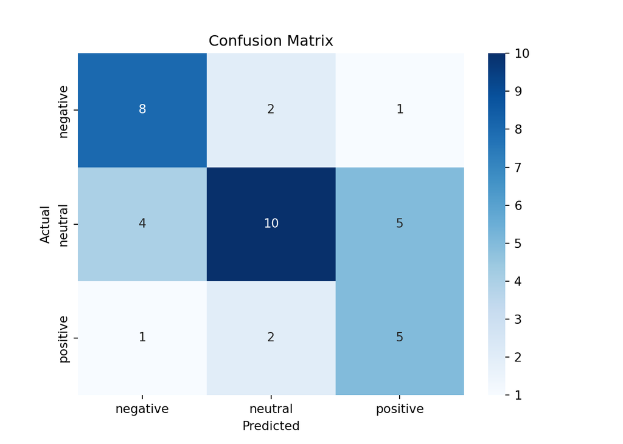

```python
# Show summary
print_model_summary(y1_test, y1_pred)
```

### Conclusions

The most important to take into consideration based on the results obtained are the False Positives and False Negatives for the negative and positive sentiments. This means that the cases we want to minimize are classifying a positive as a negative or a negative as a positive. That will be misleading to make future decisions.

*Lithium News Categories ~ Text Labeled Data*

### Data Selection

**{python}**

```python
df_sentiment = pd.read_csv('../../data/01-modified-data/clean_sentiment_analysis.csv')

# Rename columns
df_sentiment = df_sentiment.rename(columns={'ibm_label': 'label', 'ibm_content': 'text', 'ibm_score': 'sentiment'})

df_sentiment = df_sentiment[['category', 'text']]

vectorizer = CountVectorizer()

x2 = vectorizer.fit_transform(df_sentiment['text'])
y2 = df_sentiment['category']

x2_train, x2_test, y2_train, y2_test = train_test_split(x2, y2, test_size=0.2, random_state=42)

model = MultinomialNB()

model = model.fit(x2_train, y2_train)

y2_pred = model.predict(x2_test)

df_sentiment.head(5).to_csv('../../data/02-visualization-data/df_sentiment_2.csv', index=False)
```

| category | text |
| --- | --- |
| technology | If you recently moved into a new place or are just looking to update your home's security, now's a good time to do so. Though Black Friday has come and gone, Blink's video doorbell and two fourth-gen…… |
| technology | Tesla Cybertruck will usher in a new Powershare bidirectional charging feature Tesla Cybertruck will usher in a new Powershare bidirectional charging feature / The EV maker finally jumps on the ve… [+… |
| technology | The robotic line cooks were deep in their recipe, toiling away in a room tightly packed with equipment. In one corner, an articulated arm selected and mixed ingredients, while another slid back and f…… |
| technology | Renewable energies like wind and solar are clean, abundant, and cheap but notoriously unpredictable. Thats why so much time and money has been pumped into scaling energy storage solutions: we need to…… |
| general | NEW YORK -- One person was killed and six others were injured when a fire blamed on an electric bicycle battery tore through a New York City apartment, officials said Monday. The fire started at aro… … |

### Results

Below we can observe that after running the model we obtain an accuracy of approximately 0.61. We can also observe the Classification Report which show additional relevant metric used to evaluate the performance of the model. The F1 metric measures the model’s accuracy by combining the precision and recall scores by category. The general category is the one with the highest score, followed by the business one.

**{python}**

```
Accuracy: 0.6052631578947368


Classification Report:

              precision    recall  f1-score   support

    business       0.60      0.60      0.60        10
     general       0.73      0.80      0.76        20
     science       1.00      0.25      0.40         4
  technology       0.00      0.00      0.00         4

    accuracy                           0.61        38
   macro avg       0.58      0.41      0.44        38
weighted avg       0.65      0.61      0.60        38
```

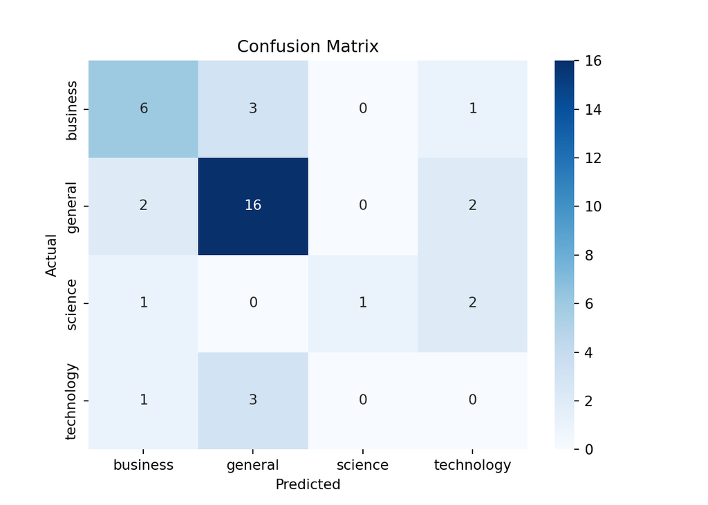

```python
# Show summary
print_model_summary(y2_test, y2_pred)
```

### Conclusions

The results obtained are useful to better understand the use of vocabulary for certain publications. This can be applied to improve writing and use the correct vocabulary to attract future readers for the publishers. In this investigation, we can dive in the classifications done in order to understand which terms are more frequent by category while including the sentiment analysis label to detect patterns.